# Midterm Practice – Transit Forecast

Miruthula Vaishnavy S

# Q1. Load the data as a monthly time series

```r
# Read and clean
dat <- read.csv("TRANSIT.csv")
names(dat) <- toupper(names(dat))
date <- as.Date(dat$DATE)

# Pick the numbers column (prefer TRANSIT if present)
val_col <- if ("TRANSIT" %in% names(dat)) "TRANSIT" else setdiff(names(dat), "DATE")[1]
y <- as.numeric(dat[[val_col]])

# Make a monthly ts
start_year  <- as.numeric(format(min(date), "%Y"))
start_month <- as.numeric(format(min(date), "%m"))
y_ts <- ts(y, frequency = 12, start = c(start_year, start_month))

start(y_ts); end(y_ts); frequency(y_ts)
```

```
## [1] 2000    1
```

```
## [1] 2023    7
```

```
## [1] 12
```

# Q2. Look at the series

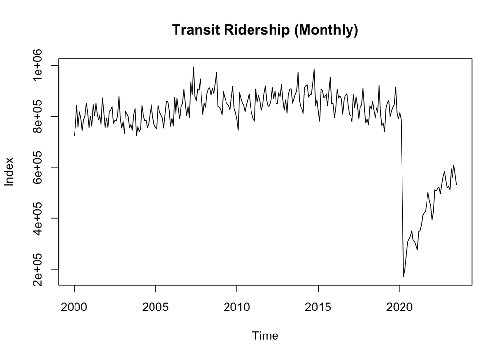

```r
plot(y_ts, xlab="Time", ylab="Index", main="Transit Ridership (Monthly)")
```

**ANSWER:** The line repeats a yearly pattern (seasonality). There are clear drops and recoveries around major events.

# Q3. Center and spread (just the basics)

```r
min_y <- min(y_ts, na.rm=TRUE)
q1_y  <- quantile(y_ts, 0.25, na.rm=TRUE)
med_y <- median(y_ts, na.rm=TRUE)
mean_y<- mean(y_ts, na.rm=TRUE)
q3_y  <- quantile(y_ts, 0.75, na.rm=TRUE)
max_y <- max(y_ts, na.rm=TRUE)
data.frame(Min=min_y, Q1=q1_y, Median=med_y, Mean=mean_y, Q3=q3_y, Max=max_y)
```

```
##        Min       Q1 Median     Mean       Q3    Max
## 25% 171450 772501.5 824766 779435.2 866163.5 993437
```

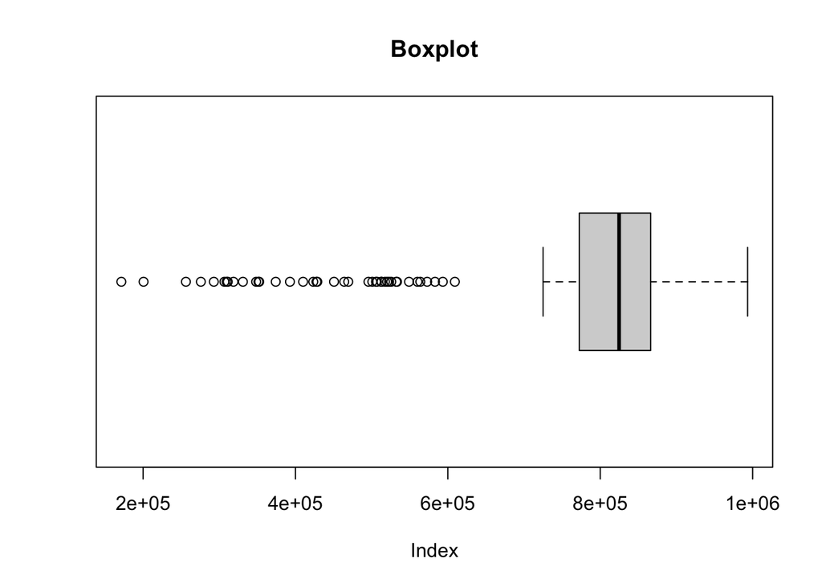

```r
boxplot(y_ts, horizontal=TRUE, main="Boxplot", xlab="Index")
```

**ANSWER:** Typical months sit between Q1 and Q3. The lowest months are rare (outliers).

# Q4. Decompose seasonality (additive and multiplicative)

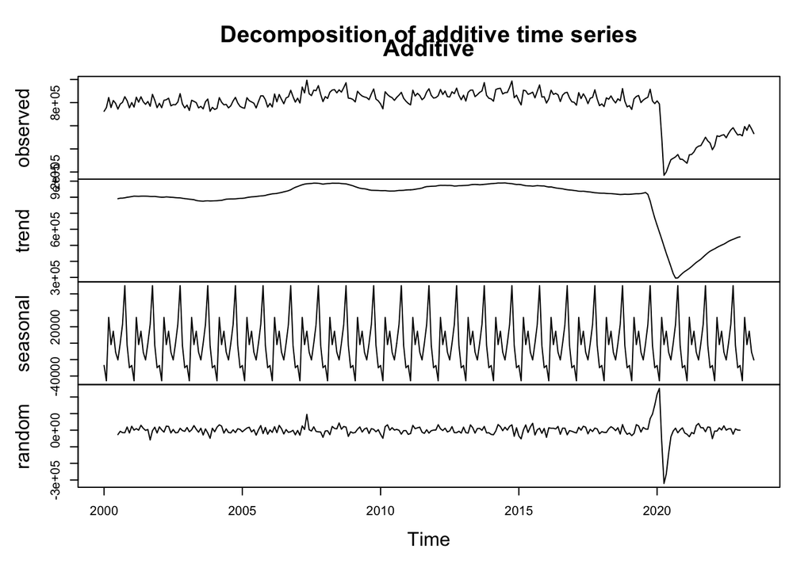

```r
d_add <- decompose(y_ts, type="additive")
d_mul <- decompose(y_ts, type="multiplicative")

plot(d_add, xlab="Time"); title("Additive")
```

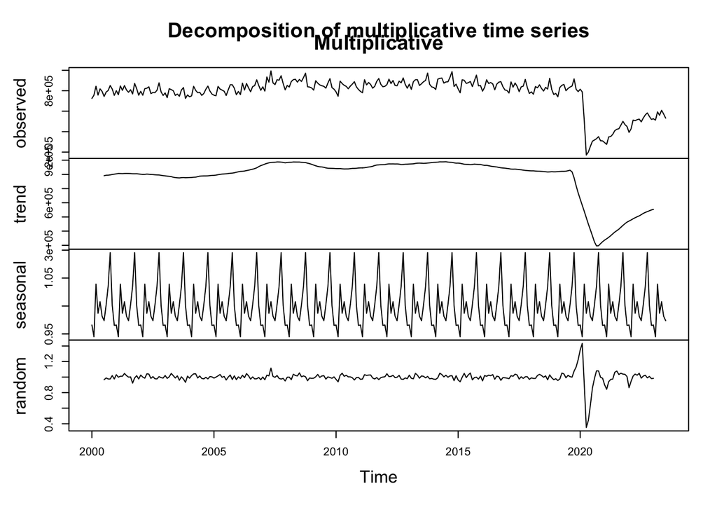

```r
plot(d_mul, xlab="Time"); title("Multiplicative")
```

```r
# Which months are high/low (additive)
add_idx <- round(d_add$figure,2)
mul_idx <- round(d_mul$figure,3)
data.frame(Month=month.abb, Additive=add_idx, Multiplicative=mul_idx)
```

```
##    Month  Additive Multiplicative
## 1    Jan -27135.96          0.966
## 2    Feb -45757.20          0.945
## 3    Mar  31380.75          1.039
## 4    Apr  -1776.45          0.987
## 5    May  14539.23          1.008
## 6    Jun -10942.36          0.982
## 7    Jul -20385.66          0.974
## 8    Aug   -189.66          1.002
## 9    Sep  22792.87          1.035
## 10   Oct  70009.19          1.096
## 11   Nov  -2605.24          1.001
## 12   Dec -29929.51          0.965
```

**ANSWER:** trend, seasonal, and remainder pieces are separated clearly. some months are consistently high (e.g., fall); some consistently low. the size of the seasonal swing looks fairly stable → additive seasonality is reasonable.

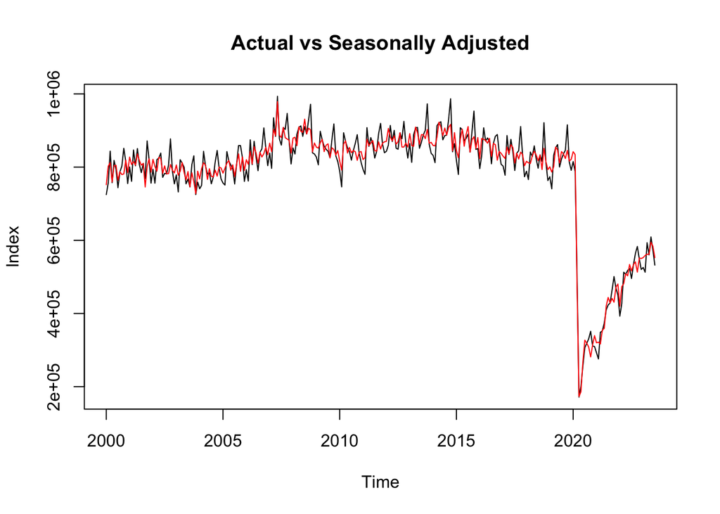

```r
# Seasonally adjusted (simple, additive)
sa <- y_ts - d_add$seasonal
plot(y_ts, type="l", xlab="Time", ylab="Index", main="Actual vs Seasonally Adjusted")
lines(sa, col="red")
```

**ANSWER:** Seasonality is strong. If the size of the seasonal swing is about the same across years, additive is fine (that’s our case).

# Q5. Naïve forecast (next 12 months)

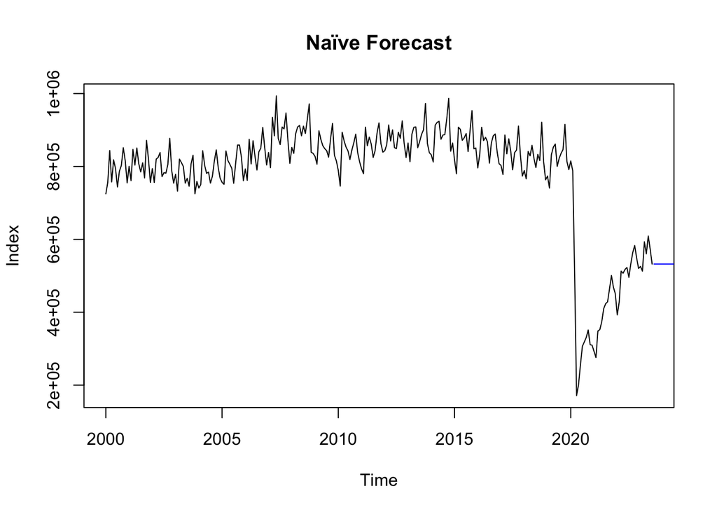

```r
# Fitted (last value) and residuals
naive_fitted <- c(NA, head(y_ts, -1))
naive_resid  <- y_ts - naive_fitted

# Forecast
h <- 12
naive_fc <- ts(rep(tail(y_ts,1), h), start=end(y_ts)+c(0,1), frequency=12)

plot(y_ts, xlab="Time", ylab="Index", main="Naïve Forecast")
lines(naive_fc, col="blue")
```

```r
# Simple accuracy (no custom function)
ok <- !is.na(naive_fitted)
e  <- y_ts[ok] - naive_fitted[ok]
ME   <- mean(e)
RMSE <- sqrt(mean(e^2))
MAE  <- mean(abs(e))
okp  <- y_ts[ok] != 0
MAPE <- if (any(okp)) mean(100*abs(e[okp])/abs(y_ts[ok][okp])) else NA
data.frame(ME=ME, RMSE=RMSE, MAE=MAE, MAPE=MAPE)
```

```
##          ME    RMSE      MAE     MAPE
## 1 -683.4326 55803.6 41483.85 6.063339
```

**ANSWER:** Naïve repeats the last month. It’s a baseline and ignores seasonality.

# Q6. Simple moving averages (3, 6, 9)

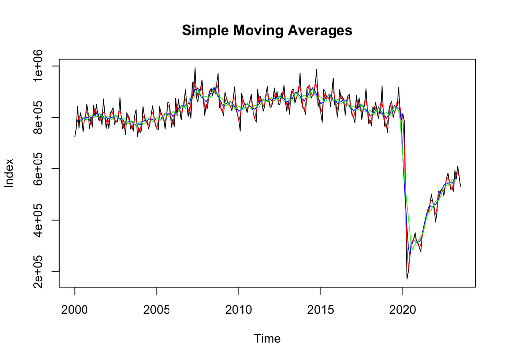

```r
sma3 <- stats::filter(y_ts, rep(1/3,3), sides=2)
sma6 <- stats::filter(y_ts, rep(1/6,6), sides=2)
sma9 <- stats::filter(y_ts, rep(1/9,9), sides=2)

plot(y_ts, xlab="Time", ylab="Index", main="Simple Moving Averages")
lines(sma3, col="red"); lines(sma6, col="blue"); lines(sma9, col="green")
```

**ANSWER:** Bigger windows look smoother, but react slower.

# Q7. Simple Exponential Smoothing (SES)

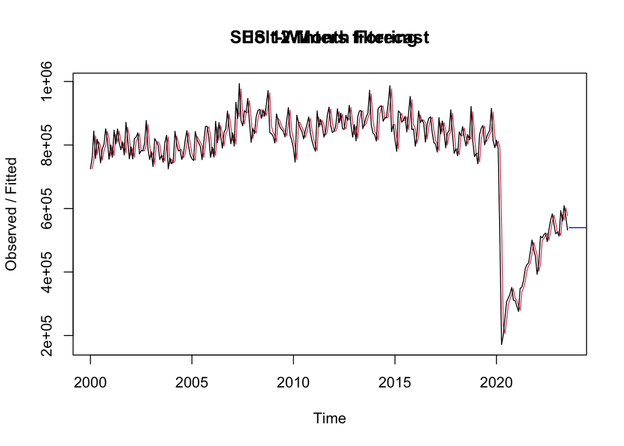

```r
ses_fit <- HoltWinters(y_ts, beta=FALSE, gamma=FALSE)
ses_fc  <- predict(ses_fit, n.ahead=12)

plot(ses_fit); lines(ts(ses_fc, start=end(y_ts)+c(0,1), frequency=12), col="blue")
title("SES 12-Month Forecast")
```

```r
# Residuals and sigma the simple way: align with ts.intersect
z_ses <- ts.intersect(y_ts, ses_fit$fitted[,1])
ses_res <- as.numeric(z_ses[,1] - z_ses[,2])
ses_res <- ses_res[is.finite(ses_res)]
sigma_ses <- if (length(ses_res)>=2) sd(ses_res) else NA
data.frame(alpha=ses_fit$alpha, sigma=sigma_ses)
```

```
##       alpha    sigma
## 1 0.8380578 55319.76
```

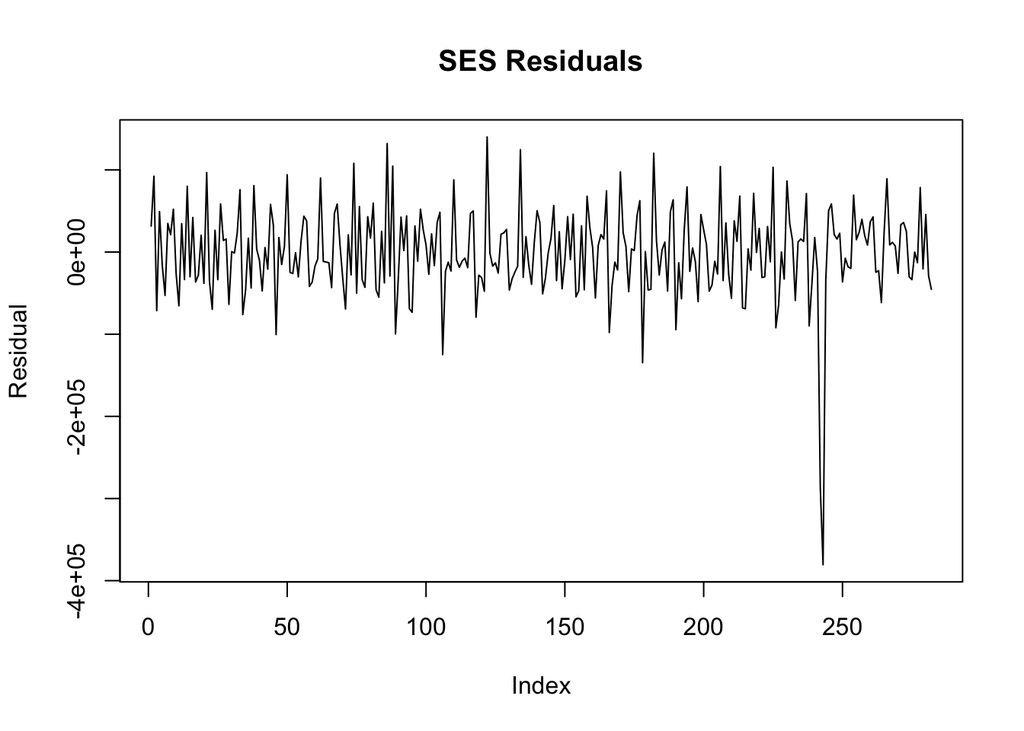

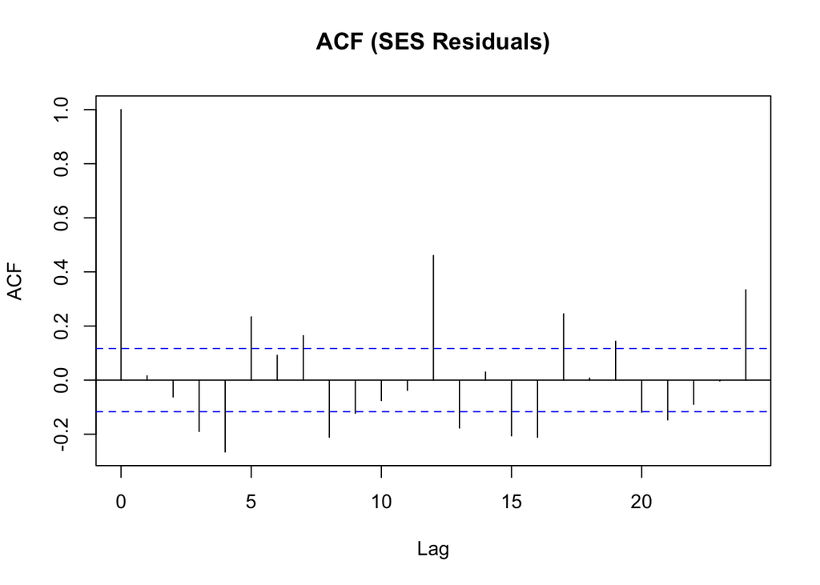

```r
if (length(ses_res) >= 2) {

  plot(ses_res, type="l", xlab="Index", ylab="Residual", main="SES Residuals")
  acf(ses_res, na.action=na.pass, main="ACF (SES Residuals)")

} else {
  cat("Not enough SES residuals to plot.\n")
}
```

**Answer:**alpha is reasonably high → the model reacts quickly to recent changes. SES captures the overall level but not the monthly seasonality. residual plots may still show seasonality/autocorrelation, meaning more structure remains.

# Q8. Holt–Winters (additive seasonality)

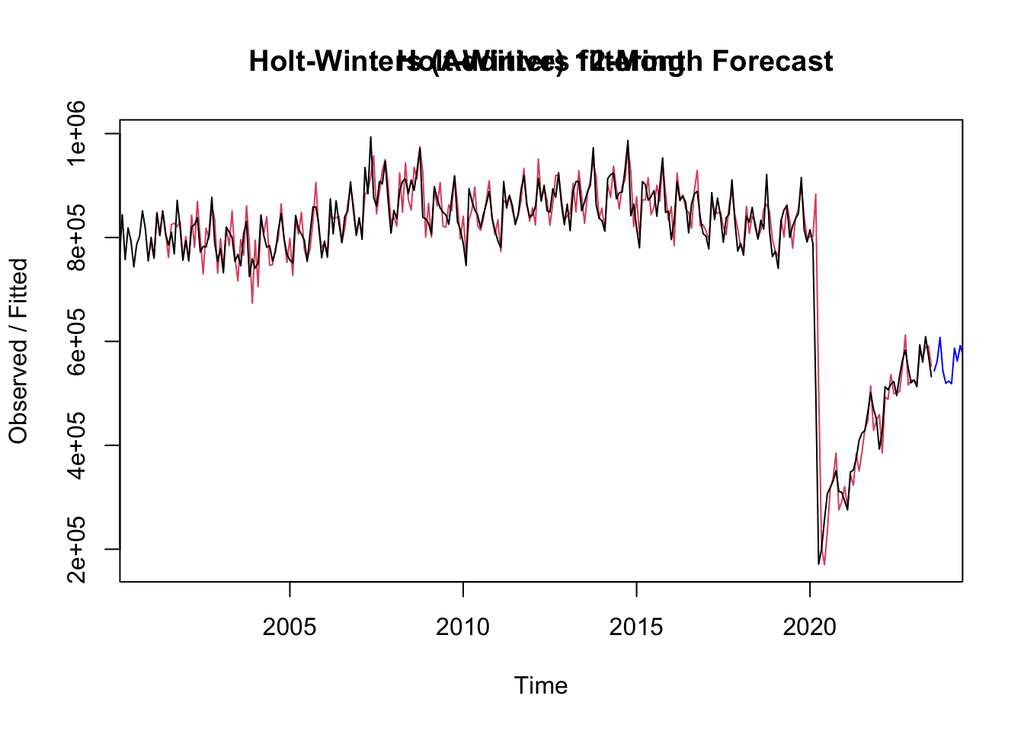

```r
hw_fit <- HoltWinters(y_ts, seasonal="additive")
hw_fc  <- predict(hw_fit, n.ahead=12)

plot(hw_fit); lines(ts(hw_fc, start=end(y_ts)+c(0,1), frequency=12), col="blue")
title("Holt-Winters (Additive) 12-Month Forecast")
```

```r
# Residuals and sigma the simple way
z_hw <- ts.intersect(y_ts, hw_fit$fitted[,1])
hw_res <- as.numeric(z_hw[,1] - z_hw[,2])
hw_res <- hw_res[is.finite(hw_res)]
sigma_hw <- if (length(hw_res)>=2) sd(hw_res) else NA

data.frame(alpha=hw_fit$alpha, beta=hw_fit$beta, gamma=hw_fit$gamma, sigma=sigma_hw)
```

```
##           alpha beta gamma   sigma
## alpha 0.9284877    0     1 43052.6
```

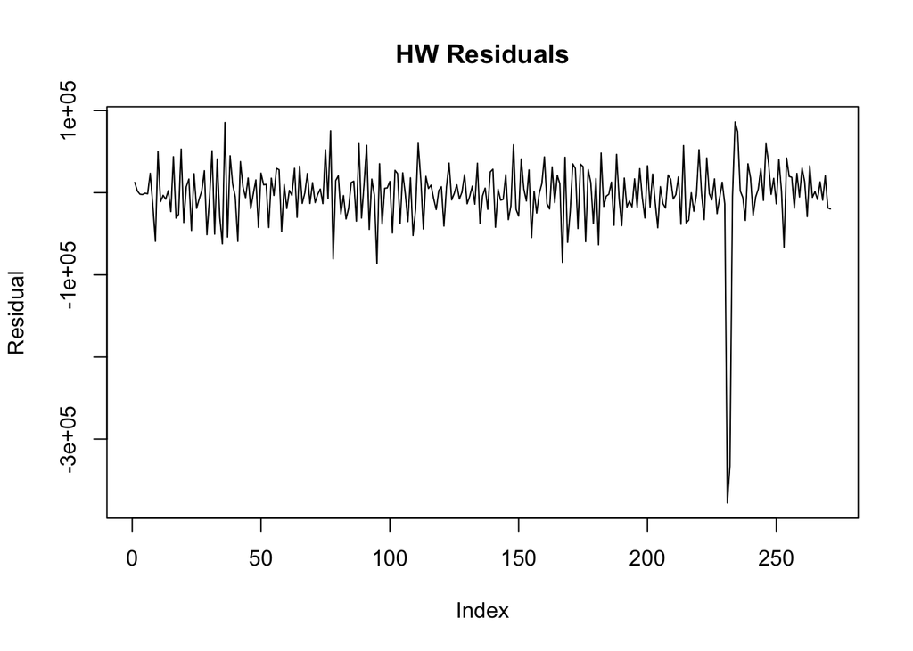

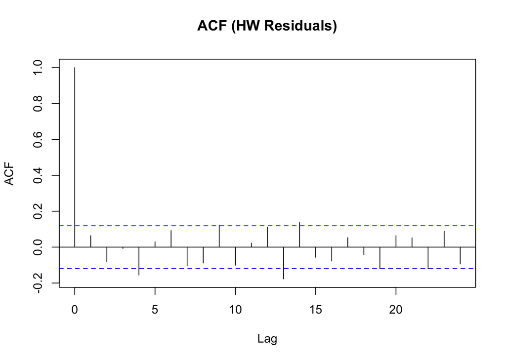

```r
if (length(hw_res) >= 2) {

  plot(hw_res, type="l", xlab="Index", ylab="Residual", main="HW Residuals")
  acf(hw_res, na.action=na.pass, main="ACF (HW Residuals)")

} else {
  cat("Not enough HW residuals to plot.\n")
}
```

# Q9. Accuracy (compare the three)

**USED CHATGPT**

```r
# Naïve accuracy already computed above
naive_ME   <- ME
naive_RMSE <- RMSE
naive_MAE  <- MAE
naive_MAPE <- MAPE

# SES accuracy
z_ses_acc <- ts.intersect(y_ts, ses_fit$fitted[,1])
a_ses <- as.numeric(z_ses_acc[,1]); f_ses <- as.numeric(z_ses_acc[,2]); e_ses <- a_ses - f_ses
ses_ME   <- mean(e_ses)
ses_RMSE <- sqrt(mean(e_ses^2))
ses_MAE  <- mean(abs(e_ses))
okp_ses  <- a_ses != 0
ses_MAPE <- if (any(okp_ses)) mean(100*abs(e_ses[okp_ses])/abs(a_ses[okp_ses])) else NA

# HW accuracy
z_hw_acc <- ts.intersect(y_ts, hw_fit$fitted[,1])
a_hw <- as.numeric(z_hw_acc[,1]); f_hw <- as.numeric(z_hw_acc[,2]); e_hw <- a_hw - f_hw
hw_ME   <- mean(e_hw)
hw_RMSE <- sqrt(mean(e_hw^2))
hw_MAE  <- mean(abs(e_hw))
okp_hw  <- a_hw != 0
hw_MAPE <- if (any(okp_hw)) mean(100*abs(e_hw[okp_hw])/abs(a_hw[okp_hw])) else NA

acc_table <- data.frame(
  Model = c("Naive","SES","HW"),
  ME    = c(naive_ME, ses_ME, hw_ME),
  RMSE  = c(naive_RMSE, ses_RMSE, hw_RMSE),
  MAE   = c(naive_MAE, ses_MAE, hw_MAE),
  MAPE  = c(naive_MAPE, ses_MAPE, hw_MAPE)
)
acc_table
```

```
##   Model         ME     RMSE      MAE     MAPE
## 1 Naive  -683.4326 55803.60 41483.85 6.063339
## 2   SES  -784.4448 55227.16 40438.30 6.044884
## 3    HW -2603.1777 43051.87 26226.83 4.266290
```

```r
best_idx <- which.min(ifelse(is.na(acc_table$RMSE), Inf, acc_table$RMSE))
data.frame(Best_By_RMSE = acc_table$Model[best_idx])
```

```
##   Best_By_RMSE
## 1           HW
```

**ANSWER:** The smallest RMSE is the winner. For seasonal monthly data, HW usually wins.

# Q10. Final takeaways:

- The data repeats a **yearly cycle** (seasonality).
- **Naïve** is a quick baseline.
- **SES** follows the level.
- **Holt–Winters (additive)** follows the level **and** the seasonal pattern.
- Forecast: expect the same seasonal ups and downs unless something unusual happens.